# 3 Module 2: Class 2

## 3.1 Formal definition of LLN

### 3.1.1 IID random variables

IID stands for independent and identically distributed.

For a sample $X_i, \ldots, X_n$:

- Independence means that their probability distributions factor
- Identical means $X_i \sim F_x$ (They all have the same distribution function).

### 3.1.2 Law of large numbers (Weak law)

- Weak LLN is about convergence in probability

**Theorem (Durrett, pg. 61):** Let $X_1, X_2, \ldots$, be iid random variables with $\mathbb{E}X_i = \mu$ and $\mathbb{E}\lvert X_i \rvert <\infty$.

If $S_n = X_1 + \ldots + X_n$, then as $n\to \infty$,
$$S_n/n \to_p \mu.$$

Better weak laws can allow some dependence among the observations and usually just require that $\mathbb{E}X_i^2 < \infty$. Check out google if you’re interested.

The strong law is about almost sure convergence and doesn’t require any further assumptions.

Intuition about LLN. What is the mean (expected value) of $S_n/n$? What is the variance of $S_n/n$?

- Mean
- Variance

Today we will

- Break the law of large numbers
- Start to talk about the central limit theorem

## 3.2 How do we use theorems in research?

1. Demonstrate that assumptions of theorem are satisfied for our case.
2. Draw conclusion about our estimator.

What if assumptions are violated?

- The average may or may not converge
- There are more precise statements that are necessary and sufficient.

## 3.3 Breaking the LLN: Cauchy distribution

- What is a Cauchy distribution (ratio of normal random variables; t RV on 1 DoF)
- The LLN can break if $\mathbb{E}\lvert X_i \rvert$ doesn’t exist (is infinite). What does this mean?

It does not have any moments ($\mathbb{E}X_i = \infty$).

Let’s use the simulations we wrote above to show that the mean of Cauchy random variables does not converge.

```r
epsilon = 0.01
nsim = 500
# Changed this to a Cauchy random variable!
RVfunc = function(n) rcauchy(n)
# maximum sample size to get to
maxn=5000
# this is the mean of the observed sample
meansout = matrix(NA, nrow=nsim, ncol=maxn)


for(sim in 1:nsim){
  cat(sim, '\t')
  # for loop through samples
  # x is the observed sample
  x = RVfunc(maxn)
  means = cumsum(x)/1:maxn
  meansout[sim,] = means
}
```

[output not shown]

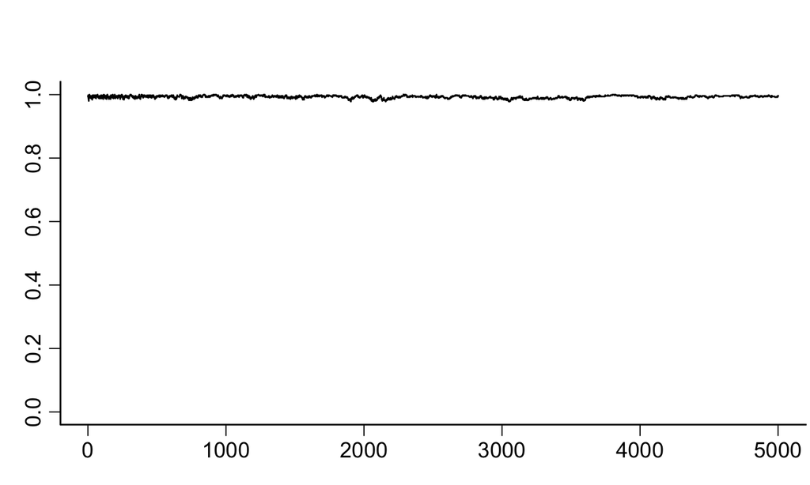

```r
P_XbarMinusp = colMeans(abs(meansout)>epsilon)

plot(1:maxn, P_XbarMinusp, type='l', xlab='', ylab='', ylim=c(0,1))
```

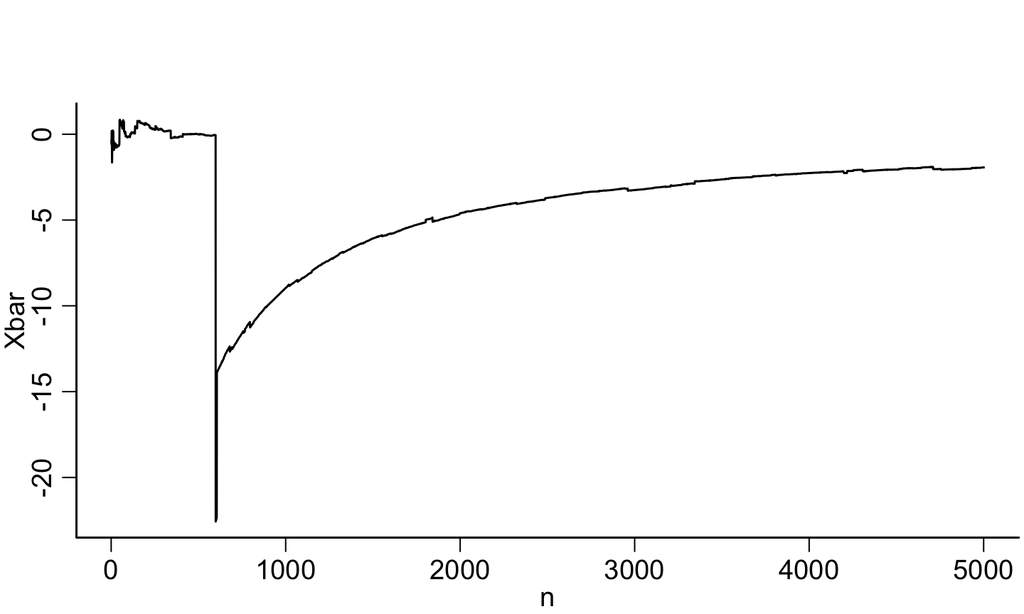

```r
plot(1:maxn, means, type='l', xlab='n', ylab='Xbar')
```

Note: we’ve already taken advantage of the LLN in the class. Does anyone know how?